# Wild boar are from mars

Do male boars move more than females?

Yelu He and Lizzy Nickell

Proposal:

Formulate at least two research questions for your project– Typical types of research questions for a methodological project start with “How can this and that be conceptualized/modelled/implemented…?” or ’ “Can this and that pattern be efficiently and effectively detected in this and that data…?”

Possible Questions:

- Is there a difference in how much males move vs. females?

Develop a research plan for investigating the above research questions.–

- What data do you need? Movement data from multiple individuals, equal number of males and females
- Where do you get this data from? From the provided boar data set
- What tools do you need? R, arcGIS (maybe)
- Will you use extensions of tools you got to know in E1 – E5?–
- Are there other R tools or even tools beyond R that you will be using in your project?

## Introduction

The wildboar (*Sus scrofa*) is native to most of Eurasia, and are considered a pest in most countries. Because of this, numerous tracking programs have been put in place to monitor their activities.

```
## # A tibble: 6 × 8
##   TierID TierName CollarID DatetimeUTC                E        N day
##    <int> <chr>       <int> <dttm>                 <dbl>    <dbl> <chr>
## 1      1 Ueli        12272 2014-05-28 21:01:14 2570390. 1204820. Tag
## 2      1 Ueli        12272 2014-05-28 21:15:18 2570389. 1204826. Abenddaemmerung
## 3      1 Ueli        12272 2014-05-28 21:30:13 2570391. 1204821. Abenddaemmerung
## 4      1 Ueli        12272 2014-05-28 21:45:11 2570388. 1204826. Abenddaemmerung
## 5      1 Ueli        12272 2014-05-28 22:00:33 2570388. 1204819. 1Nachtviertel
## 6      1 Ueli        12272 2014-05-28 22:15:16 2570384. 1204828. 1Nachtviertel
## # … with 1 more variable: moonilumination <dbl>
```

| TierID | TierName | CollarID | DatetimeUTC | E | N | day | moonilumination |
| --- | --- | --- | --- | --- | --- | --- | --- |
| 1 | Ueli | 12272 | 2014-05-28 21:01:14 | 2570390 | 1204820 | Tag | 0.0033556 |
| 1 | Ueli | 12272 | 2014-05-28 21:15:18 | 2570389 | 1204826 | Abenddaemmerung | 0.0033556 |
| 1 | Ueli | 12272 | 2014-05-28 21:30:13 | 2570391 | 1204821 | Abenddaemmerung | 0.0033556 |
| 1 | Ueli | 12272 | 2014-05-28 21:45:11 | 2570388 | 1204826 | Abenddaemmerung | 0.0033556 |
| 1 | Ueli | 12272 | 2014-05-28 22:00:33 | 2570388 | 1204819 | 1Nachtviertel | 0.0033556 |
| 1 | Ueli | 12272 | 2014-05-28 22:15:16 | 2570384 | 1204828 | 1Nachtviertel | 0.0033556 |

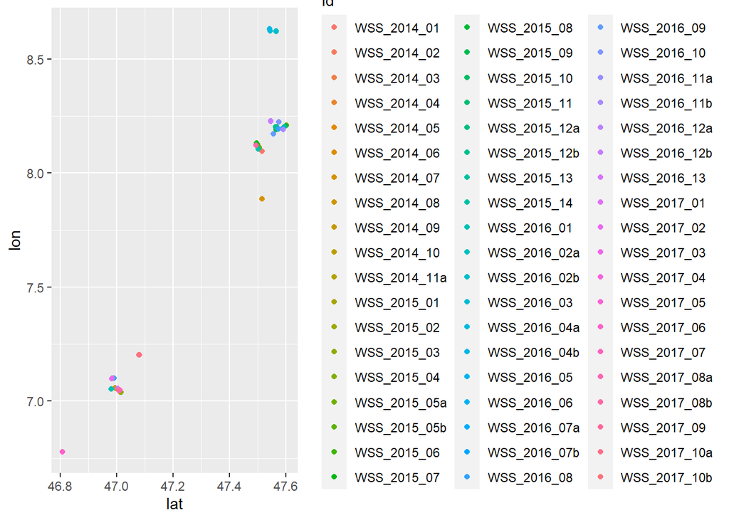

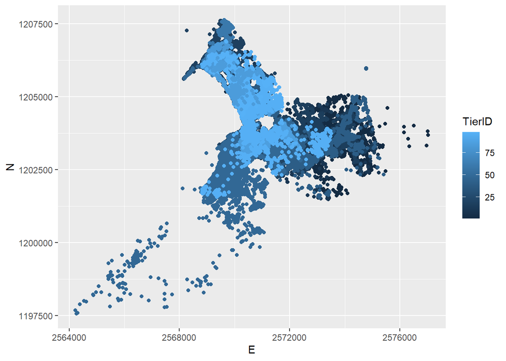

## Material and Methods

### 1 Study area

Bern / Fanel

### 2 Data

2.1 Wild boar data set description Over the past 20 years, wild boar populations have increased significantly in large parts of Europe. With the number of wild boars, the damage to agriculture also increases. Previous measures to reduce damage are very complex and associated with high costs. A new approach uses native alert and alert runs to keep wild boar away from valuable crops. The effectiveness and practicability of this deterrent system are to be tested in a scientific study.

### 3 Methods

3.1 Data pre-processing

- Data cleaning.
- Data combination to assign sexes to boar id.
- Assigning scores to movement.

3.2 Data analysis

- Comparing scores of males and females.
- Time series analysis of movement pattern.
- Circannual movement pattern analysis among genders.
- Circadian movement pattern analysis among genders.
- Modelling between environmental factors and movement pattern.

3.3 Visualization

(R visualization tools)

## Expected Results

- Pre-processed data table.
- Multi-line graphs.
- Maps of movement pattern (hot spot & clusters of male and female boars).
- Other diagrams…

## Discussion

- Validating the hypothesis that there is obvious gender differences on movement pattern of wild boar.
- Discussing the impact of environmental factors on movement of wild boar.
- Impact of our project on further research.
- Possible applications of our result.

## References

[1] Jana Zschille, Norman Stier, Mechthild Roth. Gender differences in activity patterns of American mink in Germany. European Journal of Wildlife Research, Springer Verlag, 2009, 56(2), pp.187-194. 10.1007/s10344-009-0303-2.

[2] https://www.zhaw.ch/de/forschung/forschungsdatenbank/projektdetail/projektid/842/